# Forced Turnover: Evaluating Pressing Effectiveness in Soccer

Authors

David Almona, Centre College

Natalie Rayce, Carnegie Mellon University

Published

July 25, 2025

## Introduction

Soccer is a highly tactical sport where defensive tactics not only prevent the opposing team from scoring but can create immediate attacking opportunities. Pressing, a defensive tactic where opposing players apply coordinated pressure on the offensive ball carrier to force turnovers, has been at the core of elite teams like Liverpool under Jürgen Klopp and Manchester City under Pep Guardiola (commonly known as “gegenpressing”). They have shown that effective pressing can turn defense into goal-scoring opportunities within seconds.

This study centers around the question: Can the effectiveness of a press in soccer be predicted using factors such as spatial context, pressing dynamics, game context, and situational factors? We have defined our measure of effectiveness as forcing a turnover within 5 seconds of pressing initiation.

## Data

Match information, dynamic events, and XY tracking data are provided by SkillCorner. They use artificial intelligence and deep learning to detect moving objects in broadcast videos and extract data. Match information includes the data and time of the games, home and away team names, pitch dimensions, referee information, and other game-level details. Dynamic events include on-ball and off-ball activities such as passes, shots, tackles, recoveries, off-ball runs, goals, and many others. Each event also has a timestamp, location coordinates, and player identification. XY tracking data includes the identities, locations, and movements of all 22 players and the ball throughout the full 90 minutes at a rate of 10 frames per second (10 Hz). Since this data is extracted from broadcast video, SkillCorner uses its technology to extrapolate the coordinates of players outside of the camera’s field of view.

The dataset contains 520 matches played in the 2023 season of Major League Soccer (MLS), the professional soccer league in North America. The dynamic events for 18 of the 520 matches were not provided by SkillCorner because they did not pass their quality check and were, therefore, unusable for this analysis.

## Methods

### Detecting pressing sequences with XY tracking data

While StatsBomb-360 data and possibly other soccer tracking providers tag a pressure or pressing event, SkillCorner does not. To identify pressing events, we initially defined the “pressure zone” as any area within 6 meters of the ball carrier. However, according to **[Andrienko et al., 2017]**, this approach is too simplistic and does not account for the directions players are facing or moving towards. So, we chose to adopt the new approach they had proposed, where the “pressure zone” is elliptical (or oval) rather than circular. The distance limits are determined by the following formula:

$$L = D_{back} + (D_{front} - D_{back})(z^3 + 0.3z) / 1.3$$
where:

$L$ = the maximum distance limit for effective pressure at angle $\theta$ (the radius of the oval-shaped pressure zone at any given angle)

$D_{back}$ = the maximum distance limit when the presser is positioned behind the ball carrier

$D_{front}$ = the maximum distance limit when the presser is positioned in front of the ball carrier

$z$ = $(1 - cos \theta) / 2$

$\theta$ = the angle between the vector from the ball carrier to the center of the attacking goal (which we determined as the threat direction) and the vector from the ball carrier to the presser

[Andrienko et al., 2017] determined the distance thresholds $D_{back}$ and $D_{front}$ to be 3m and 9m, respectively, based on consultation with football (soccer) experts. He later performed an experiment to verify these parameters.

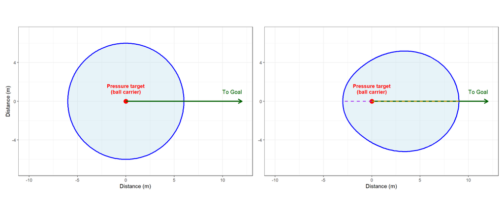

Figure [x]: The pressure zone. Left panel shows our initial circular pressure zone approach. Right panel shows the oval pressure zone method from Andrienko et al. (2017), which accounts for directional threat. The shaded blue area is where defending players would be considered as applying pressure to the ball carrier.

### Grouping pressing sequences

Individual pressing actions were grouped into pressing sequences based on how close they happened in time. We defined a pressing sequence as a continuous period where at least one defender from the same team maintained pressing behavior, allowing for brief interruptions of up to 1.5 seconds (15 frames). In other words, if a pressing defender leaves the pressure zone or is no longer actively pressing, but another defender exhibits pressing behavior within 1.5 seconds, the sequence remains active. However, if the next press begins more than 1.5 seconds after the previous press, a new pressing sequence begins.

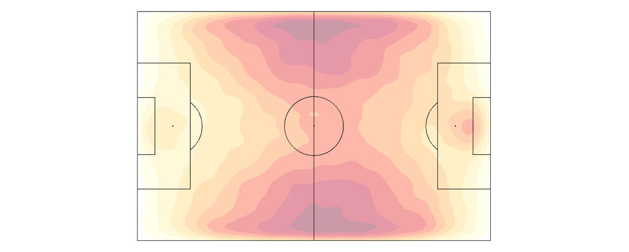

Figure [x]: Heatmap showing the pressing patterns across the MLS 2023 season. The highest concentration of pressing occurs in the middle third of the field on both sides, where teams look to win the ball back in midfield areas to create quick attacking opportunities. Note: the home team is made to always attack left-to-right, the away team goes right-to-left.

### Measuring an effective press

Since the goal of pressing is to regain ball possession or force a turnover by the attacking team, **[Lee et al., 2025]** highlighted that the impact of pressing should extend beyond immediate ball possession. This is mainly because pressing can force the attacking team into tight positions, which may increase the likelihood of an eventual turnover in the next few seconds or actions. They tested different success criteria for pressing, such as regaining possession after 7 seconds or after 4 actions, among others, but their analysis focused on regaining possession within 5 seconds of the pressing initiation. As a result, we decided to use the same method and assess the effectiveness of a pressing sequence based on whether the pressing team forced a turnover within 5 seconds of the start of the pressing sequence.

### Feature engineering

After data cleaning and processing, we had 31 features that were used for training our model. These included:

- Spatial Context: Ball carrier position, distance to boundaries, field third, etc.
- Pressing Dynamics: Number of defenders, approach velocity, passing options, etc.
- Game Context: Score, game state (winning/losing/drawing), time remaining, etc.
- Situational Factors: How the ball carrier gained possession (pass reception, interception, etc.), incoming pass characteristics (distance, height, range), etc.

## Analysis

##### Model Performance

The XGBoost model marginally outperformed the logistic regression model across all evaluation metrics, as seen in *Table [x]*.

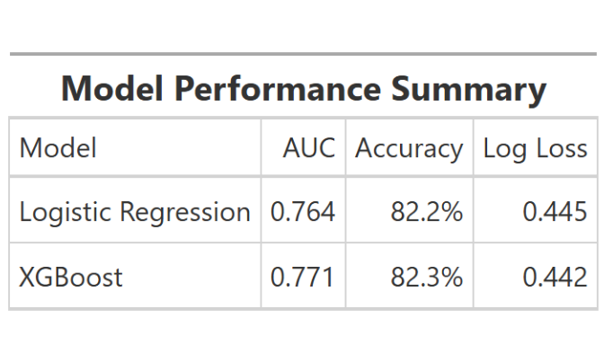

##### Model Calibration

*Figure X* shows the calibration plot of our XGBoost model, plotting predicted turnover probabilities against actual turnover rates. In a perfectly calibrated model, the blue line, which is our model, should align exactly with the red dotted diagonal line (perfect calibration).

Our model shows reasonably good calibration overall, with some deviation from perfect. This tells us that our XGBoost model is better at predicting when turnovers are unlikely to occur than when they are likely to occur.

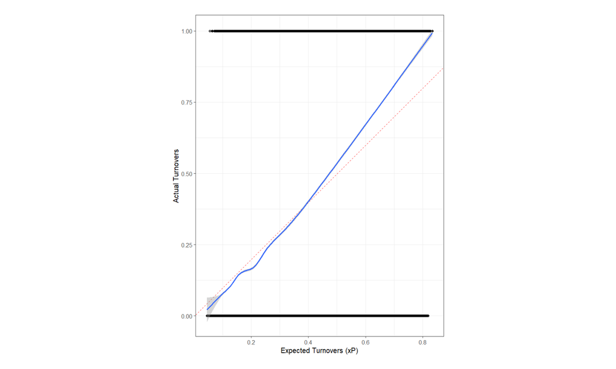

Figure [x]: Calibration plot

## Results

##### Team Pressing Performane

Significant variation existed in pressing effectiveness across MLS teams during the 2023 season (*Figure [X]*). Based on our model, the New York Red Bulls were the most effective pressing team, forcing approximately 7 more turnovers per game than our model predicted.

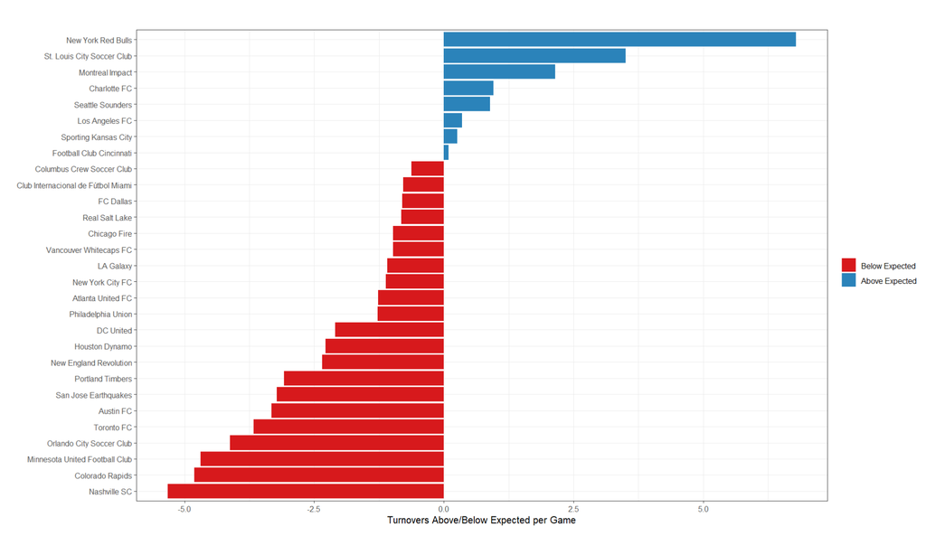

Figure [x]: Positive values (blue) indicate teams forcing more turnovers than predicted, while negative values (red) show underperformance. New York Red Bulls led MLS in pressing effectiveness, while Nashville SC struggled most relative to expectations.

##### Pressing Volume vs. Pressing Effectiveness

[figure not shown]

Figure [x]: Teams in the upper-right quadrant combine high pressing frequency with high effectiveness

## Appendix: A quick tutorial

This a Quarto document. To learn more about Quarto see https://quarto.org. You can use the Render button to see what it looks like in HTML.

### Text formatting

Text can be bolded with **double asterisks** and italicized with *single asterisks*. Monospace text, such as for short code snippets, uses `backticks`. (Note these are different from quotation marks or apostrophes.) Links are written [like this](http://example.com/).

Bulleted lists can be written with asterisks:

- Each item starts on a new line with an asterisk.
- Items should start on the beginning of the line.
- Leave blank lines after the end of the list so the list does not continue.

Mathematics can be written with LaTeX syntax using dollar signs. For instance, using single dollar signs we can write inline math: $(-b \pm \sqrt{b^2 - 4ac})/2a$.

To write math in “display style”, i.e. displayed on its own line centered on the page, we use double dollar signs:
$$x^2 + y^2 = 1$$

### Code blocks

Code blocks are evaluated sequentially when you hit Render. As the code runs, `R` prints out which block is running, so naming blocks is useful if you want to know which one takes a long time. After the block name, you can specify [chunk options](https://yihui.org/knitr/options/). For example, `echo` controls whether the code is printed in the document. By default, output is printed in the document in monospace:

```
                   mpg cyl disp  hp drat    wt  qsec vs am gear carb
Mazda RX4         21.0   6  160 110 3.90 2.620 16.46  0  1    4    4
Mazda RX4 Wag     21.0   6  160 110 3.90 2.875 17.02  0  1    4    4
Datsun 710        22.8   4  108  93 3.85 2.320 18.61  1  1    4    1
Hornet 4 Drive    21.4   6  258 110 3.08 3.215 19.44  1  0    3    1
Hornet Sportabout 18.7   8  360 175 3.15 3.440 17.02  0  0    3    2
Valiant           18.1   6  225 105 2.76 3.460 20.22  1  0    3    1
```

Chunk options can also be written inside the code block, which is helpful for really long options, as we’ll see soon.

```
                   mpg cyl disp  hp drat    wt  qsec vs am gear carb
Mazda RX4         21.0   6  160 110 3.90 2.620 16.46  0  1    4    4
Mazda RX4 Wag     21.0   6  160 110 3.90 2.875 17.02  0  1    4    4
Datsun 710        22.8   4  108  93 3.85 2.320 18.61  1  1    4    1
Hornet 4 Drive    21.4   6  258 110 3.08 3.215 19.44  1  0    3    1
Hornet Sportabout 18.7   8  360 175 3.15 3.440 17.02  0  0    3    2
Valiant           18.1   6  225 105 2.76 3.460 20.22  1  0    3    1
```

### Figures

If a code block produces a plot or figure, this figure will automatically be inserted inline in the report. That is, it will be inserted exactly where the code block is.

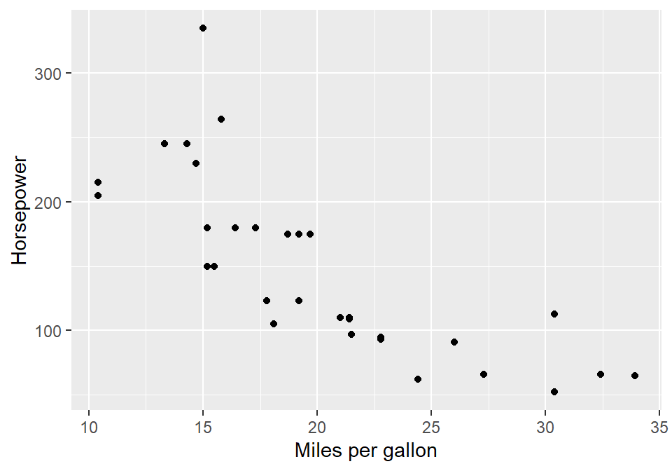

This is a caption. It should explain what’s in the figure and what’s interesting about it. For instance: There is a negative, strong linear correlation between miles per gallon and horsepower for US cars in the 1970s.

Notice the use of `fig-width` and `fig-height` to control the figure’s size (in inches). These control the sizes given to `R` when it generates the plot, so `R` proportionally adjusts the font sizes to be large enough.

### Tables

Use the `knitr::kable()` function to print tables as HTML:

|  | mpg | cyl | disp | hp | drat | wt | qsec | vs | am | gear | carb |
| --- | --- | --- | --- | --- | --- | --- | --- | --- | --- | --- | --- |
| Mazda RX4 | 21.0 | 6 | 160 | 110 | 3.90 | 2.620 | 16.46 | 0 | 1 | 4 | 4 |
| Mazda RX4 Wag | 21.0 | 6 | 160 | 110 | 3.90 | 2.875 | 17.02 | 0 | 1 | 4 | 4 |
| Datsun 710 | 22.8 | 4 | 108 | 93 | 3.85 | 2.320 | 18.61 | 1 | 1 | 4 | 1 |
| Hornet 4 Drive | 21.4 | 6 | 258 | 110 | 3.08 | 3.215 | 19.44 | 1 | 0 | 3 | 1 |
| Hornet Sportabout | 18.7 | 8 | 360 | 175 | 3.15 | 3.440 | 17.02 | 0 | 0 | 3 | 2 |

We can summarize model results with a table. For instance, suppose we fit a linear regression model:

```r
model1 <- lm(mpg ~ disp + hp + drat, data = mtcars)
```

It is *not* appropriate to simply print `summary(model1)` into the report. If we want the reader to understand what models we have fit and what their results are, we should provide a nicely formatted table. A simple option is to use the `tidy()` function from the `broom` package to get a data frame of the model fit, and simply report that as a table.

Predicting fuel economy using vehicle features.

| Term | Estimate | SE | t | p |
| --- | --- | --- | --- | --- |
| (Intercept) | 19.34 | 6.37 | 3.04 | 0.01 |
| disp | -0.02 | 0.01 | -2.05 | 0.05 |
| hp | -0.03 | 0.01 | -2.34 | 0.03 |
| drat | 2.71 | 1.49 | 1.83 | 0.08 |